# Lab Log

Daniel Padfield

### 18/10/2017

- Autoclaved the soil again
- Autoclaved 1 L of DI millicule water
- Autoclaved 1 L of 0.6% soft agar
- Autoclaved a spoon to weigh out soil
- Got some $SBW25\phi2$ from Floh. Around 1 mL at 7.26 x 10<sup>8</sup>.
  - Grow up overnight
  - Transfer 60 µl of bacteria and 10 µl of phage (around 7 x 10 <sup>6</sup> pfus) into 6 mL of KB agar
  - Should give a concentration of around 10<sup>8</sup> phage/mL
  - Done this in triplicate
- Grow up *lacZ* and *WT* strains overnight. Should give concentration of around ~10<sup>8</sup> cells in 60 µl.
- Do these in triplicate
- Added 60 µL of frozen overnight culture from first experiment (18/08/2017 *lacZ* and WT)

**Retrospectively work out density of the overnight stocks and phage**

### 19/10/2017

- Put 80g of soil into each 10cm x 10cm microcosm
  - Used autoclaved spoon
  - Placed scale in laminar flow hood (cleaned with ethanol before and after)
- Placed 5 mL (~ 200 µl per microcosm) of *lacZ* and WT into separate 12 mL centrifuge tubes
  - Centrifuged for 15 minutes at max speed (~4500 r.p.m) on big centrifuge
  - Want to get to 5 mL per microcosm for inoculating (~ 125 mL in total)
  - Resuspended pellet into 2250 µl, vortexed and placed 620 µl, 620 µl and 810 µl into three different falcon tubes
  - Filled these three falcon tubes up to 40 mL, 40 mL and 45 mL respectively
    - This guaranteed the same concentration of sample in each falcon tube
  - Placed 5 mL of *lacZ* or WT strain into each microcosm
  - Froze (-80 ºC) 900 µl of inoculate in 900 µl of glycerol (25% final concentration)
- In the no phage treatments, we added 5 mL of M9
- Added 5 mL of phage to phage treatments
  - Place 900 µl of bacteria + phage into three centrifuge tubes
  - Add 100 µl (10%) chloroform into each tube (under fume hood)
  - Vortex rigorously
  - Centrifuge for 2-3 minutes at full speed (minifuge)
  - Take out supernatant and placed in a single tube (took out 800 µl of each tube)
  - Put 40 mL of M9 into 6 tubes
  - Added 400 µl into each tube (~100 fold dilution from the initial stock)
  - Shake each tube and add 5 mL into each microcosm
- Place microcosms into the 26 ºC incubator (Level 1 incubator room)

### 22/10/2017

- setup 2 WT microcosms up for spot assays of phage
- used a crystal from T<sub>0</sub>
- autoclaved 2 L of KB agar. Put in small autoclave

### 23/10/2017

- phage spot test 10<sub>-1</sub> to 10<sub>-8</sub>
  - Floh’s phage (7.26 x 10<sup>8</sup>)
  - Phage we inoculated with
  - Extra phage tube (should have lower concentration)
  - blank plate
- plated T<sub>0</sub> of WT and *lacZ* *P. fluorescens*

### 24/10/2017

- phage spot test was no good (streaky)
- likely that we did not wait long enough for the spot to dry
- set up more T<sub>0</sub> bacteria overnight

### 25/10/2017

- phage spot assay again
- plating only 4 spots per plate instead of 8
- counted T<sub>0</sub> counts (plated 30 µl)
  - *lacZ* @ 10<sup>-4</sup>: 18
  - WT @ 10<sup>-4</sup>: 64

### 26/10/2017

- check phage spot, 10<sup>-6</sup> looks to be the correct dilution
- further counts are done by putting the 10 µl phage into the 1% bacteria soft agar
  - vortex and plate
  - leave to dry
  - incubate overnight

### 30/10/2017

- grow up some T<sub>0</sub> bacteria overnight

### 31/10/2017

- serial dilution of phage to 10<sup>-6</sup>
- 50 µl bacteria + 10 µl phage + 5 ml soft agar
  - vortex
  - pour
- set samples up for inoculated phage, floh’s phage stock and our phage dregs (each in triplicate)
- in 28 ºC incubator overnight

### 01/11/2017

- looked at phage spots (10<sup>-6</sup> dilution)
- calculated how many phage are there

$$Phage\ concentration = \frac{number\ of\ plaques}{dilution\ factor\ \times\ volume added}$$

Volume added is almost always 10 µl. I wrote a mini function to calculate this

```r
d <- data.frame(dregs = c(3,4,6), phage = c(6,2,4))

# back calculate number in there
# PFU/ml = plaque number / (dil fac * volume added)
plaq_num <- function(x, dilfac){return(x/(dilfac*0.01))}

d <- dplyr::mutate_at(d, c('dregs', 'phage'), plaq_num, dilfac = 10^-6)

knitr::kable(d)
```

| dregs | phage |
| --- | --- |
| 3e+08 | 6e+08 |
| 4e+08 | 2e+08 |
| 6e+08 | 4e+08 |

```r
# concentration of phage added
mean(d$phage)
```

```
## [1] 4e+08
```

```r
# concentration of other phage
mean(d$dregs)
```

```
## [1] 433333333
```

- sampled all soil microcosms (after 13 days)
  - ~2g of soil into a 12 mL centrifuge tube (with ~ 7 glass beads)
    - sample using the big end of a 5 mL pipette and weigh on scales under hood
  - add 10 mL of M9
  - vortex for ~ 1 minute
  - add 900 µl of sample to 900 µl of 50% glycerol and freeze at -80 ºC (bacteria + phage)
  - make phage suspension for each tube
    - add 900 µl of sample to centrifuge tube
    - add 100 µl of chloroform under fume hood
    - vortex
    - centrifuge at full speed for 4 minutes
    - put supernatant into separate tube
      - samples 1-17 800 µl, samples 18-48 750 µl
- names of samples
- 1-12: WT no phage
- 13-24: *lacZ* no phage
- 25-36: WT + phage
- 37-48: *lacZ* + phage
- Autoclaved things
  - 2 empty 500 mL bottles
  - M9 salts x10 (500 mL)
    - converted the weight of $Na_{2}HPO_{4}$ to the amount of $Na_{2}HPO_{4}.7H_{2}O$ needed.
    - MW of $Na_{2}HPO_{4}.7H_{2}O$ is 268. MW of $Na_{2}HPO_{4}$ is 142.
    - to convert from weight of $Na_{2}HPO_{4}$ to $Na_{2}HPO_{4}.7H_{2}O$ is to multiply by $\frac{268}{142}$
  - 1 L of DI water
  - 2 L hard agar
  - centrifuge tubes.

| sample | weight_g |
| --- | --- |
| 1 | 2.1 |
| 2 | 2.0 |
| 3 | 1.9 |
| 4 | 2.0 |
| 5 | 2.0 |
| 6 | 2.0 |
| 7 | 2.0 |
| 8 | 2.0 |
| 9 | 2.1 |
| 10 | 1.9 |
| 11 | 2.2 |
| 12 | 2.1 |
| 13 | 2.1 |
| 14 | 1.9 |
| 15 | 2.2 |
| 16 | 2.2 |
| 17 | 1.9 |
| 18 | 2.2 |
| 19 | 2.0 |
| 20 | 2.3 |
| 21 | 2.3 |
| 22 | 2.2 |
| 23 | 1.9 |
| 24 | 2.1 |
| 25 | 2.1 |
| 26 | 2.2 |
| 27 | 1.9 |
| 28 | 2.0 |
| 29 | 2.2 |
| 30 | 2.3 |
| 31 | 2.0 |
| 32 | 2.2 |
| 33 | 2.2 |
| 34 | 2.2 |
| 35 | 2.0 |
| 36 | 2.0 |
| 37 | 2.3 |
| 38 | 1.9 |
| 39 | 2.2 |
| 40 | 1.9 |
| 41 | 2.2 |
| 42 | 2.0 |
| 43 | 2.0 |
| 44 | 2.2 |
| 45 | 2.1 |
| 46 | 2.2 |
| 47 | 2.2 |
| 48 | 2.1 |

### 02/11/2017

- set up phage spot tests of all soil phage suspensions against ancestral WT on soft agar.
  - just checking for presence/absence of phage
  - 5 mL per plate, 4 spots per plate, 12 spots in total
  - important to let the spot dry before moving
- poured plates (all Xgal)

### 03/11/2017

- all no phage treatments had no phage and all phage treatments had phage
- plated all the bacteria + phage treatments at 10<sup>-4</sup> and 10<sup>-5</sup> (30 µl)
  - left on bench over the weekend

### 06/11/2017

- counted all the plates
  - all still had bacteria in and were not obviously contaminated (Yays)
- picked 20 colonies from each sample and placed in KB media in 48 well plates
  - 750 µl of KB media
  - used matchsticks
- grown statically for 2 days at 26 ºC

### 08/11/2017

- put 500 µl of 50% glycerol into each well (final concentration 20%)
- froze in the -80 ºC
- autoclaved
  - 2x 800 mL hard agar
  - 2x 800 mL soft agar

### 13/11/2017

- prep for sampling soil microcosms tomorrow. Labelled samples. Booked downstairs hood with power access.

### 14/11/2017

- sampled all 48 microcosms
- froze 900 µl of bacteria + phage in 900 µl of 50% glycerol (final concentration equals 25%)
- phage sample in fridge
  - 1-12: 750 µl
  - 13-48: 600 µl
- setup soft agar plates of ancestral bacteria and did phage spot assays

| sample | weight_g |
| --- | --- |
| 1 | 2.2 |
| 2 | 2.2 |
| 3 | 2.3 |
| 4 | 2.1 |
| 5 | 2.2 |
| 6 | 2.1 |
| 7 | 2.1 |
| 8 | 2.0 |
| 9 | 2.0 |
| 10 | 2.0 |
| 11 | 2.2 |
| 12 | 2.1 |
| 13 | 2.0 |
| 14 | 2.2 |
| 15 | 2.2 |
| 16 | 2.0 |
| 17 | 2.1 |
| 18 | 2.3 |
| 19 | 2.0 |
| 20 | 2.0 |
| 21 | 2.1 |
| 22 | 2.0 |
| 23 | 2.1 |
| 24 | 2.2 |
| 25 | 2.0 |
| 26 | 2.0 |
| 27 | 2.2 |
| 28 | 2.0 |
| 29 | 2.0 |
| 30 | 2.0 |
| 31 | 2.3 |
| 32 | 2.1 |
| 33 | 2.2 |
| 34 | 2.2 |
| 35 | 2.1 |
| 36 | 2.1 |
| 37 | 2.1 |
| 38 | 2.3 |
| 39 | 2.0 |
| 40 | 2.0 |
| 41 | 2.3 |
| 42 | 2.0 |
| 43 | 2.2 |
| 44 | 2.2 |
| 45 | 2.0 |
| 46 | 2.2 |
| 47 | 2.0 |
| 48 | 2.0 |

### 15/11/2017

- all phageless samples are still phageless, all phage samples still contain phage

### 16/11/2017

- plated all T<sub>2</sub> samples
  - 10<sup>-3</sup> and 10<sup>-4</sup>
  - 30 µl of on plate
- **used undiluted M9 x10 on Tuesday!!!**
- made up 400 mL of M9 salts x10 for autoclave

### 20/11/2017

- counted plates.
  - Most are ok at 10<sup>-3</sup>. Counts were much lower. Want to be certain that the reduction in abundance is not due to using concentrated M9.
- full sample again, T<sub>3</sub>.
  - Took 700 µL samples of phage
- setup overnight stock of ancestral bacteria
- autoclaved 2400 mL of KB agar

| sample | weight_g |
| --- | --- |
| 1 | 2.0 |
| 2 | 2.0 |
| 3 | 1.9 |
| 4 | 2.3 |
| 5 | 2.0 |
| 6 | 2.2 |
| 7 | 2.0 |
| 8 | 2.3 |
| 9 | 2.0 |
| 10 | 2.1 |
| 11 | 2.2 |
| 12 | 2.1 |
| 13 | 2.0 |
| 14 | 2.1 |
| 15 | 2.0 |
| 16 | 2.3 |
| 17 | 2.3 |
| 18 | 2.1 |
| 19 | 2.2 |
| 20 | 2.0 |
| 21 | 2.1 |
| 22 | 2.1 |
| 23 | 2.1 |
| 24 | 2.2 |
| 25 | 2.1 |
| 26 | 2.0 |
| 27 | 2.2 |
| 28 | 2.1 |
| 29 | 2.1 |
| 30 | 2.0 |
| 31 | 2.2 |
| 32 | 2.0 |
| 33 | 2.1 |
| 34 | 2.1 |
| 35 | 2.2 |
| 36 | 2.2 |
| 37 | 2.0 |
| 38 | 2.1 |
| 39 | 2.1 |
| 40 | 2.0 |
| 41 | 2.1 |
| 42 | 2.2 |
| 43 | 2.0 |
| 44 | 2.3 |
| 45 | 2.2 |
| 46 | 2.1 |
| 47 | 2.1 |
| 48 | 2.0 |

### 21/11/2017

- plated all 48 T<sub>3</sub> samples at 10<sup>-2</sup> and 10<sup>-3</sup>
- re-plated all T<sub>2</sub> replicates that did not contain > 20 colonies at 10<sup>-2</sup>
- poured ~150 Xgal plates. Stored in the cold room
- autoclaved two boxes of ependorfs
- put beads in Virkon to clean
- phage spot assay on phage extractions from T<sub>3</sub>. Used ancestral bacteria as the bacterial lawn

### 23/11/2017

- all T<sub>3</sub> samples were ok (> 30 colonies at 10<sup>-3</sup>) apart from 12 and 37
  - 12 an 37 were re-plated at 10<sup>0</sup> and 10<sup>-1</sup>
- picked 20 colonies from each sample and placed in KB media in 48 well plates
  - 750 µl of KB media
  - used matchsticks
- grown statically for 2 days at 26 ºC
- Checked phage spot assays

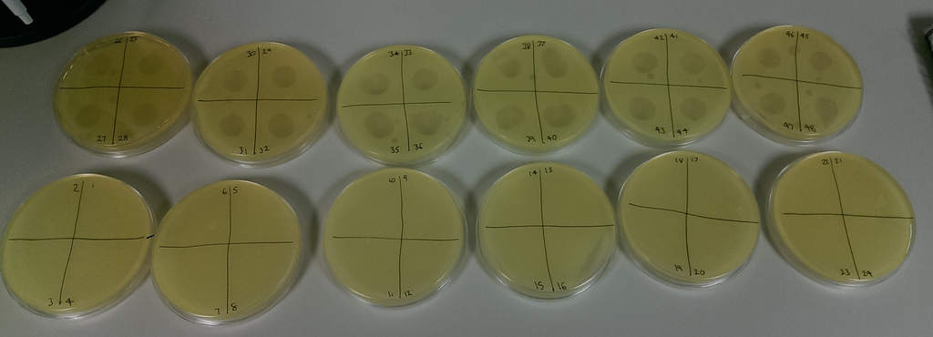

**Figure 1. phage spot assays are on point**

### 25/11/2017

- picked colonies from 12 (10<sup>0</sup>) and 37 (10<sup>-1</sup>)
  - incubate for two days
- put 500 µl of 50% glycerol into each well of the other replciates that had been growing for two days (final concentration 20%)
- froze in the -80 ºC

### 27/11/2017

- autoclaved 4L of KB hard agar

### 28/11/2017

- poured 2L of KB agar into square plates (Xgal)
- put 180 µl of KB media into 96 well plates
- grew T<sub>F</sub> clones up overnight from frozen isolates (phage present microcosms only, 25-48)
  - placed in 28 ºC incubator

### 29/11/2017

- look at coevolution of phage and host using streak plates
- streak each clone against contemporary phage, ancestral phage, a paired WT phage and a paired *lacZ* phage
- spot 30 µl of each phage onto a square plate, let run down the plate then let it dry
- 1 plate per microcosm
- streak clones across the line of phage using matchsticks and the template

### 30/11/2017

- looked like it didnt work
- everything grew everywhere, even the controls
- set up an ancestral overnight

### 01/12/2017

- set up some phage spot assays of random phage against the ancestral phage
- did some streak assays

### 02/12/2017

- phage streak worked
- all phage spots worked
- **current hypothesis of problem is that we did not mix the phage properly**

### 05/12/2017

- grew up all clones overnight
- poured lots of square plates

### 06/12/2017

- did another phage streak day

### 08/12/2017

- counted the phage streaks. Processed these but they do not look as expected.
- autoclaved 4 L of hard KB agar
- autoclaved 1 L of KB media

### 10/12/2017

- setup isolated clones overnight in 180 µl of KB media
- poured many square plates
- amplifying T<sub>F</sub> phage in ancestral WT overnight
  - 60 µl of ancestor and 10 µl phage
- setup some phage spot assays (P.27, P.38, P.41)
  - spotted 10 µl from 10<sup>-1</sup> to 10<sup>–8</sup>

### 11/12/2017

- Unfortunately some of the lids of the phage amplifications had come off
- Reset these today
- Plated all the phage with ancestral bacteria at 10<sup>-3</sup>

### 12/12/2017

- Counted phage

### 13/12/2017

- Did phage streaks using comb

### 14/12/2017

- Marked phage streaks

### 03/01/2018

**State of play** - It is worrying that there is not fluctuating selection. That there is no variation in resistance across phages - Resistance to ancestral phage by communities without phage has never been observed

**Options** - Do phage spot tests on some replicates to see if same results hold (whether it is the test) - Re-isolate some replicates - Test resistance of ancestral clones - Test presence of phage in no phage treatments with larger phage volume - Test resistance after T<sub>1</sub>

- Am going to use 4 communities for the tests here.
  - 1, 10 (controls that had resistance)
  - 37, 42 communities that had resistance
- Grow each clone up overnight in 200 µl of KB media
- Grow Ancestral clone up overnight in KB media

### 04/01/2017

- Phage spot tests on community 1, 10, 37 and 42
- 1 and 10 are controls that showed resistance. Phage these are against are ancestral and their own phage
- 37 went against ancestral phage, contemporary phage and phage 38 and phage 25
- 42 went against ancestral phage, contemporary phage and phage 41 and phage 30
- 7.5 µl spots were used
- put in all ~200 µl of culture into 5 mL of soft agar
- placed at 28 ºC overnight
- looked at whether there is phage in the controls just at low concentration
  - put 100 µl of bacteria (WT) and 100 µl of “phage” (1 and 10) in 5 mL of soft agar
- plated WT (10<sup>-4</sup> and 10-<sup>-5</sup>)
- plated 1, 10, 37 and 42 to re-isolate clones (from T<sub>2</sub>)
- plated 30 µl as always

### 05/01/2018

- Lots of the phage spots were not dense enough (in terms of bacteria)
- Was able to identify when samples were susceptible but more difficult to identify resistance
- For the WT ancestor and the 1 and 10 “phage” plates, there was only one phage spot on the 10 plate. There was no spot on the 1 plate. Think the spot on 10 could just be contamination but not sure
- Autoclaved KB media, soft agar and hard agar

### 06/01/2018

- Picked 20 clones for each community of WT ancestor, 1, 10, 37 and 42. Grown at 26 ºC in 120 µl of KB media

### 07/01/2018

- Poured plates
- Labelled everything ready for tomorrow
- Grew up communities overnight (1, 10, 37, 42) in 6 mL of KB media @ 180 rpm @ 28 ºC

### 08/01/2018

- Added 100 µl of 50% glycerol to isolates in 96 well plate and placed in the -80 ºC freezer
- Did the phage spot assays again, using 200 µl of culture per 5 mL of soft agar.
- Some flasks are not that dense but should be enough volume for most for a nice bacterial lawn

### 09/01/2018

- No difference between ancestral phages, between the bottle previously used and one previously kept separate
- Controls:
  - 1 had a resistance proportion of 0.64 (9 resistant, 5 susceptible, 5 of the replicates were no good, out of a total of 19)
  - 10 had no resistance (20 susceptible)
- Communities with phage
  - 37 had complete resistance (17 resistant, 3 replicates no good)
  - 42 had a resistance proportion of 0.1875 (3 resistant, 13 susceptible, 4 no good)

These are not dissimilar to the results pre-Christmas using the phage streak assays

### 10/01/2017

- Grew up new isolates overnight in KB media

### 11/01/2017

- Phage streak assay again
- Ancestral isolates: 0 resistance
- 1 and 10 isolates (controls): 1/20 resistant
- 37: ~6 resistant
- 42: ~8 resistant

Key is that for 37 and 42, if they have resistance for their contemporary phage, they are also resistant to all other phages including the ancestral phage. This goes against the Science paper by Pedro and Stineke’s previous experiment.

Consequently I do not believe it is worth pursuing this experiment. SIGH.

**Next steps**

- Grow up new isolates overnight in media and phage streak them
- Do I need more phage (do this anyway). Grow ancestral up overnight
- Check T<sub>1</sub> for the difference in resistance
- Check more of the controls for resistance
- Pour some extra square plates